# Rain Forest Data

Sai Laasya Gorantla

2025-02-13

```r
## Installing libraries
if(!require('pacman'))
  install.packages('pacman')
```

```r
## Loading libraries
pacman :: p_load(
  RColorBrewer,
  plotly,
  janitor,
  tidytext,
  patchwork,
  colorspace,
  dplyr,
  dbscan,
  lubridate,
  readr,
  GGally,
  reshape2,
  tidyr,
  FNN,
  zoo,
  lubridate)
```

# Carbondioxide Calibarations of zone3 file.

Chosen the the carbondioxide values from the mtn_tower_co2 file and performing the data cleaning process. Skipping the unrequired lines and checking with the first 5 rows and the null values from each column of the dataframe.

```r
#Loading the zone_3 file
co2_zone3_1 <- read.csv('data/SCADA__MTNTWRCO2.csv', skip = 2)


#Making a copy of original dataset
co2_zone3 <- data.frame(co2_zone3_1)

## Reading the first 5 rows
head(co2_zone3)
```

```
##      ID            TIMESTAMP TRENDFLAGS STATUS    VALUE TRENDFLAGS_TAG
## 1 63893  2019/08/25 00:00:00          0      0 514.7742            { }
## 2 63894  2019/08/25 00:15:00          0      0 515.1938            { }
## 3 63895  2019/08/25 00:30:00          0      0 517.5016            { }
## 4 63896  2019/08/25 00:45:00          0      0 517.7954            { }
## 5 63897  2019/08/25 01:00:00          0      0 517.4597            { }
## 6 63898  2019/08/25 01:15:00          0      0 521.1104            { }
##   STATUS_TAG
## 1       {ok}
## 2       {ok}
## 3       {ok}
## 4       {ok}
## 5       {ok}
## 6       {ok}
```

```r
# Check for missing values in each column
colSums(is.na(co2_zone3))
```

```
##             ID      TIMESTAMP     TRENDFLAGS         STATUS          VALUE
##              0              0             14             14             14
## TRENDFLAGS_TAG     STATUS_TAG
##              0              0
```

```r
##Missing values
sum(is.na(co2_zone3))
```

```
## [1] 42
```

There are 14 missing values of carbondioxide for the zone-3. So to deal with the those 14 value we are using linear-polation to fill the gaps.

```r
#Filling out the column
co2_zone3 <- co2_zone3 |> mutate(VALUE = na.approx(VALUE, na.rm = FALSE))

# Check for missing values in each column
colSums(is.na(co2_zone3))
```

```
##             ID      TIMESTAMP     TRENDFLAGS         STATUS          VALUE
##              0              0             14             14              0
## TRENDFLAGS_TAG     STATUS_TAG
##              0              0
```

### Data Processing for CO₂ Calibration in Zone 3 (2020)

The analysis focuses exclusively on 2020 data from Zone 3 for carbon dioxide calibration. The timestamp data has been converted to a standardized datetime format (YYYY-MM-DD HH:MM:SS) to ensure temporal consistency across all sensor readings.

As the Carbondioxide sensors record measurements at 15-minute intervals, each complete day should contain 96 observations (24 hours × 4 readings per hour). We are systematically verifying the data completeness by:

1. Checking for days with fewer than 96 readings, which may indicate sensor malfunctions or data gaps
2. Identifying any temporal patterns in missing data (e.g., consistent gaps at specific times)
3. Documenting all instances of incomplete daily records before proceeding with calibration

This quality control step is critical for ensuring the reliability of subsequent calibration procedures and trend analyses, as missing or irregular observations could potentially bias the results. All data validation processes are being carefully documented to maintain transparency in the analytical workflow.

```r
# Convert TIMESTAMP to a datetime format
co2_zone3 <- co2_zone3 %>% mutate(TIMESTAMP = as.POSIXct(TIMESTAMP, format = "%Y/%m/%d %H:%M:%S"))

# Filter for the year 2020
co2_zone3 <- co2_zone3 %>% filter(year(TIMESTAMP) == 2020)



##  Counting the number as the readings takes place for every 15 min
readings_per_day_z3 <- co2_zone3 |> group_by(Date = date(TIMESTAMP)) %>% summarize(Readings = n())

##Missing date readings
missing_day <- readings_per_day_z3 |> filter(Readings != 96)

cat("Missing dates")
```

```
## Missing dates
```

```r
print(missing_day)
```

```
## # A tibble: 1 × 2
##   Date       Readings
##   <date>        <int>
## 1 2020-02-25       95
```

### Data Gap Identification and Imputation

During the validation of 2020 CO₂ measurements from Zone 3, we identified an incomplete daily record on February 25th, containing only 95 observations instead of the expected 96 readings. The missing measurement corresponds specifically to the 09:30 timestamp.

A notable pattern emerges in the subsequent 09:45 reading, where the trendflag value of 1 with the annotation {start} suggests a possible sensor recalibration or system restart event. While the exact nature of this event requires further investigation with domain experts, we have implemented a conservative imputation approach to maintain data continuity.

```r
# Check the data type of the column
class(co2_zone3$VALUE)
```

```
## [1] "numeric"
```

```r
# Calculate the mean value for the year 2020
mean_value <- mean(co2_zone3$VALUE)
print(mean_value)
```

```
## [1] 428.1858
```

The mean value for the VALUE column is 428.1858.

#### Missing Timestamp Handling

```r
# Create new row for missing timestamp
missingrow <- data.frame(ID = "0000",
                          TIMESTAMP = as.POSIXct("2020-02-25 09:30:00"),
                          VALUE = mean_value,
                          TRENDFLAGS = 0,
                          STATUS = 0,
                          TRENDFLAGS_TAG = "{}",
                          STATUS_TAG = "{ok}"

)

# Insert into dataset and arranging the time stamp according to the time.
co2_zone3 <- co2_zone3 |>
  bind_rows(missingrow) |>
  arrange(TIMESTAMP)
```

#### Daily Aggregation & Visualization

Calculates daily mean CO₂ concentrations from 15-minute interval data. Visualizes trends with a line plot (highlighting daily fluctuations) and reference lines. Provides quality control by revealing data patterns and anomalies

```r
# Group by day and calculate the mean value per day
mean_value_per_day <- co2_zone3 |>
  group_by(Date = date(TIMESTAMP)) |>
  summarize(Mean = mean(VALUE))

# View the result
print(mean_value_per_day)
```

```
## # A tibble: 67 × 2
##    Date        Mean
##    <date>     <dbl>
##  1 2020-01-01  424.
##  2 2020-01-02  427.
##  3 2020-01-03  427.
##  4 2020-01-04  426.
##  5 2020-01-05  420.
##  6 2020-01-06  431.
##  7 2020-01-07  417.
##  8 2020-01-08  413.
##  9 2020-01-09  430.
## 10 2020-01-10  421.
## # ℹ 57 more rows
```

### Visualizing Daily Carbondioxide Concentration Trends in 2020

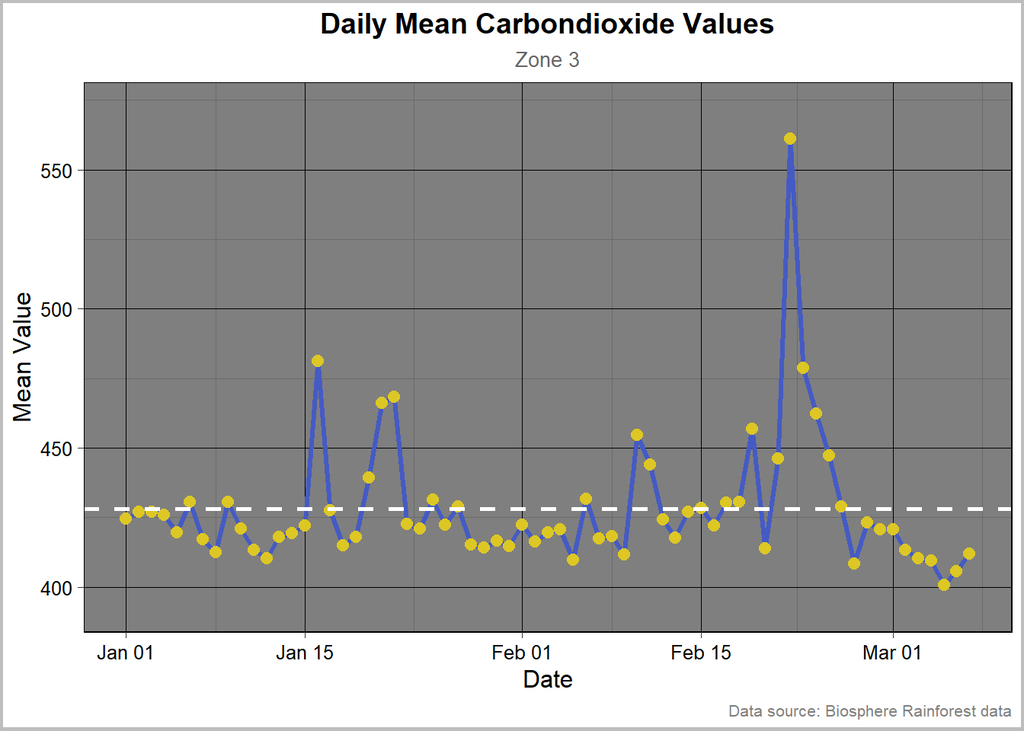

```r
# Plot daily mean values
ggplot(mean_value_per_day,
       aes(x = Date, y = Mean)) +
  geom_line(color = "#455BC4", linewidth = 1.2) +
  geom_point(color = "#DDC724" , size = 2.5, alpha = 1) +
  geom_hline(yintercept = mean(mean_value_per_day$Mean),
             linetype = "dashed",
             size = 1,
             color = "white")+
  labs(title = "Daily Mean Carbondioxide Values",
       subtitle = "Zone 3",
       x = "Date",
       y = "Mean Value",
        caption = "Data source: Biosphere Rainforest data") +
  theme_dark(base_size = 12)+
  theme(
    plot.background = element_rect(fill = "white", color = "grey", linewidth =  1.5),
    panel.grid.major = element_line(color = "black", linewidth = 0.3),
    panel.border = element_rect(color = "black", fill = NA, linewidth = 0.5),
    plot.title = element_text(face = "bold", size = 14, hjust = 0.5),
    plot.subtitle = element_text(color = "gray40", hjust = 0.5, size = 10),
    plot.caption = element_text(color = "gray50", size = 8),
    axis.title = element_text(color = "black"),
    axis.text = element_text(color = "black")

    ) +
   scale_y_continuous(
    limits = c(min(mean_value_per_day$Mean)*0.98, max(mean_value_per_day$Mean)*1.02)
  )
```

#### Outlier Detection in carbondioxide Measurements

This analysis identifies anomalous carbondioxide readings in the 2020 dataset using a K-Nearest Neighbors (KNN) approach (k=6). Key steps include:

Outlier Detection: Calculated distances between each point and its 6 nearest neighbors

Thresholding: Flagged values above the 95th percentile distance as outliers

Visual Validation: Plotted results to inspect spatial and temporal patterns of anomalies

The method helps distinguish true sensor anomalies from natural carbondioxide fluctuations while preserving valid extreme values.

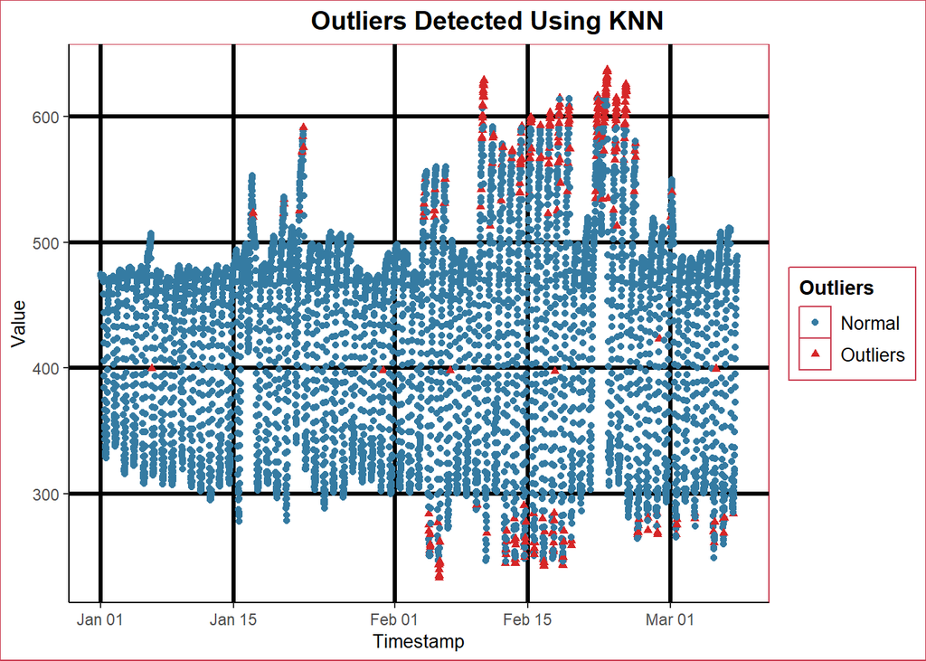

```r
# Extract the VALUE column for outlier detection
data_knn <- as.matrix(co2_zone3$VALUE)

# Detecting outliers using KNN (k = 6)
knn_distances <- kNNdist(data_knn, k = 6)

# Use the 95th percentile as the threshold
outlier_threshold <- quantile(knn_distances, 0.95)
outliers <- knn_distances > outlier_threshold

# outlier information to the original data
co2_zone3$Is_Outlier <- outliers

# Visualize the outliers
ggplot(co2_zone3,
       aes(x = TIMESTAMP, y = VALUE, color = Is_Outlier, shape = Is_Outlier)) +
  geom_point(size = 1.5) +
  scale_color_manual(values = c("#357BA2", "#D62728"),
                     labels = c("Normal", "Outliers")) +
  scale_shape_manual(values = c(16,17),
                     labels = c("Normal", "Outliers")) +
  labs(title = "Outliers Detected Using KNN",
       x = "Timestamp",
       y = "Value") +
  guides(
    color = guide_legend(title = "Outliers"),
    shape = guide_legend(title = "Outliers")
  ) +
  theme_classic()+
  theme(
    plot.title = element_text(face = "bold", size = 14, hjust = 0.7),
    plot.background = element_rect(color = "#CA3D51"),
    axis.title = element_text(size = 10),
    panel.grid.major = element_line(color = "black", linewidth = 1.1),
    panel.background = element_rect(colour = "#CA3D51"),
    legend.background = element_rect(color = "#CA3D51", fill ="white", linewidth = 0.5),
    legend.title = element_text(face = "bold"),
    legend.text = element_text(size = 10)
    )
```

### Relative Humidity for the North East Tower.

### Data Quality Summary: North East Tower Relative Humidity

Null Value Analysis: - Complete dataset verification: No missing values found in any columns - Column-wise validation: All 6 sensor columns show 0 null entries - Full-table assessment: Total null count across entire dataset = 0

Key Findings: 1. The relative humidity dataset exhibits complete data integrity 2. All sensor readings (100m, 300m, 700m, 1300m, 2000m) recorded values at every timestamp 3. No gaps detected in the 15-minute interval measurements

Identifying the data : Filters 2020 humidity data, verifies 15-minute reading completeness (96/day), and identifies dates with missing measurements.

```r
## Reading the humidity data file by skipping the two rows and put the header as False for not considering the name of the column
humidity1 <- read.csv("data/NE_Tower_Relative humidity.csv", skip = 4, header = FALSE)

#Copying te original dataframe
ne_humidity <- data.frame(humidity1)


# Taking off the null column the V7 by selecting 6 columns only
ne_humidity <- ne_humidity[, 1:6]


# Reassigning the column names as needed
colnames(ne_humidity) <- c("DateTime", "TRF_NETower_100_HMP45", "TRF_NETower_300_HMP45","TRF_NETower_700_HMP45","TRF_NETower_1300_HMP45","TRF_NETower_2000_HMP45")
```

##Checking for the top 5 rows and also null values in the entire table and also for each column.

```r
## Reading the first 5 rows
head(ne_humidity)
```

```
##           DateTime TRF_NETower_100_HMP45 TRF_NETower_300_HMP45
## 1 2019/08/25 00:00                  91.6                  97.9
## 2 2019/08/25 00:15                  91.6                  97.9
## 3 2019/08/25 00:30                  91.6                  97.9
## 4 2019/08/25 00:45                  91.6                  98.0
## 5 2019/08/25 01:00                  91.6                  98.0
## 6 2019/08/25 01:15                  91.5                  98.0
##   TRF_NETower_700_HMP45 TRF_NETower_1300_HMP45 TRF_NETower_2000_HMP45
## 1                  94.4                   95.6                   89.3
## 2                  94.5                   95.7                   89.2
## 3                  94.5                   95.7                   89.2
## 4                  94.5                   95.6                   89.1
## 5                  94.6                   95.6                   89.1
## 6                  94.6                   95.6                   89.1
```

```r
# Check for missing values in each column
colSums(is.na(ne_humidity))
```

```
##               DateTime  TRF_NETower_100_HMP45  TRF_NETower_300_HMP45
##                      0                      0                      0
##  TRF_NETower_700_HMP45 TRF_NETower_1300_HMP45 TRF_NETower_2000_HMP45
##                      0                      0                      0
```

```r
##Missing values
sum(is.na(ne_humidity))
```

```
## [1] 0
```

```r
## Filtering out the '2020' data from humidity dataframe
ne_humid_2020 <- ne_humidity |> filter(year(DateTime) == 2020)


##  Counting the number as the readings takes place for every 15 min
readings_per_day_humid <- ne_humid_2020 |> group_by(Date = date(DateTime)) %>% summarize(Readings = n())

##Missing date readings
missing_day_humid <- readings_per_day_humid |> filter(Readings != 96)

cat("Missing dates")
```

```
## Missing dates
```

```r
print(missing_day_humid)
```

```
## # A tibble: 0 × 2
## # ℹ 2 variables: Date <date>, Readings <int>
```

#### Sensor Calibration: Relative Humidity Corrections for NorthEast Tower with Relative Humidity.

Generated new columns for calibrated values at each tower height (100m, 300m, 700m, 1300m, 2000m)

```r
#Generating new columns for the humidity dataframe
ne_humid_2020 <- ne_humid_2020 %>%
  mutate(
    RH_NE_100_Corr  = TRF_NETower_100_HMP45  * 1.038 + 1.0,
    RH_NE_300_Corr  = TRF_NETower_300_HMP45  * 0.986 - 2.1,
    RH_NE_700_Corr  = TRF_NETower_700_HMP45  * 1.055 - 6.8,
     RH_NE_1300_Corr = TRF_NETower_1300_HMP45 * 0.9213 + 5.6,
    RH_NE_2000_Corr = TRF_NETower_2000_HMP45 * 0.9889 + 3.0,
   )

# View the updated dataframe
head(ne_humid_2020)
```

```
##           DateTime TRF_NETower_100_HMP45 TRF_NETower_300_HMP45
## 1 2020/01/01 00:00                 60.20                 62.09
## 2 2020/01/01 00:15                 60.20                 62.01
## 3 2020/01/01 00:30                 60.09                 61.85
## 4 2020/01/01 00:45                 59.83                 61.47
## 5 2020/01/01 01:00                 59.65                 61.37
## 6 2020/01/01 01:15                 59.33                 61.30
##   TRF_NETower_700_HMP45 TRF_NETower_1300_HMP45 TRF_NETower_2000_HMP45
## 1                 51.78                  51.32                  47.78
## 2                 51.33                  51.20                  47.72
## 3                 51.48                  51.09                  47.52
## 4                 51.32                  50.78                  47.38
## 5                 50.69                  50.70                  47.12
## 6                 50.90                  50.45                  46.99
##   RH_NE_100_Corr RH_NE_300_Corr RH_NE_700_Corr RH_NE_1300_Corr RH_NE_2000_Corr
## 1       63.48760       59.12074       47.82790        52.88112        50.24964
## 2       63.48760       59.04186       47.35315        52.77056        50.19031
## 3       63.37342       58.88410       47.51140        52.66922        49.99253
## 4       63.10354       58.50942       47.34260        52.38361        49.85408
## 5       62.91670       58.41082       46.67795        52.30991        49.59697
## 6       62.58454       58.34180       46.89950        52.07959        49.46841
```

#### Performed the calculation as by taking the formula and it’s the value for each column that is each sensor at particular heights.

```r
# Select columns starting with "RH"
rh_columns <- grep("RH", names(ne_humid_2020), value = TRUE)

# Subset the data using the selected column names
rh_data <- ne_humid_2020[, rh_columns]

# Calculate the mean of those columns
ne_humid_mean <- colMeans(rh_data)

# Print the result
cat("Mean of the columns in the realtive humidity columns of the dataframe")
```

```
## Mean of the columns in the realtive humidity columns of the dataframe
```

```r
print(ne_humid_mean)
```

```
##  RH_NE_100_Corr  RH_NE_300_Corr  RH_NE_700_Corr RH_NE_1300_Corr RH_NE_2000_Corr
##        78.50448        73.57304        68.11770        70.69086        68.35277
```

#Outliers for the North East Tower of Relative Humidity

[figure not shown]

[figure not shown]

[figure not shown]

[figure not shown]

[figure not shown]

```r
# Select columns starting with "RH"
rh_columns <- grep("^RH", names(ne_humid_2020), value = TRUE)

# Considering values of those columns
humidity_rh <- ne_humid_2020[, rh_columns]

# Function to detect outliers using KNN
detect_outliers <- function(data) {

  # Compute KNN distances
  knn_dist <- knn.dist(as.matrix(data), k = 6)

  # Calculate the 95th percentile of distances for each point
  quantile_distances <- apply(knn_dist, 1, function(x) quantile(x, 0.95))

  # Identify outliers as points where the distance exceeds the 95th percentile
  outliers <- quantile_distances > quantile(quantile_distances, 0.95)

  return(outliers)
}

# Initialize a list to store outlier results
outlier_results <- list()

# Detect outliers for each column
for (col in rh_columns) {
  column_data <- humidity_rh[[col]]
  outliers <- detect_outliers(column_data)
  outlier_results[[col]] <- outliers
}

# Visualize outliers for each column
for (col in rh_columns){
  # Create a data frame for plotting
  plot_data <- data.frame(
    Index = 1:nrow(humidity_rh),
    Value = humidity_rh[[col]],
    Outlier = outlier_results[[col]]
  )

  # Plot the data with outliers highlighted
  p<- ggplot(plot_data, aes(x = Index, y = Value, color = Outlier)) +
    geom_point(size = 2, alpha = 0.6) +
    scale_color_manual(values = c("TRUE"= "#5e66ad","FALSE" = "#42bd35" ),
                       labels = c("Outlier", "Normal"),
                       guide = guide_legend(shape = 16)) +
    labs(title = paste("Outliers in", col),
         x = "ObservationIndex",
         y = "Humidity Value") +
    theme_linedraw()+
    theme(
      plot.background = element_rect(colour = "blue", linewidth = 1),
      panel.background = element_rect(colour = "blue", linewidth = 1),
      plot.title = element_text(hjust = 0.6, face = "bold"),
      axis.title = element_text(size = 12),
      legend.background = element_rect(colour = "blue"),
      legend.title = element_text(hjust = 0.5, color = "black", face = "bold")
      )

  print(p)
}
```

### Data Quality Summary: North East Tower Temperature data

Null Value Analysis: Complete dataset verification: No missing values found in any columns

Key Findings: 1. The relative temperature dataset exhibits complete data integrity 2. All sensor readings (100m, 300m, 700m, 1300m, 2000m) recorded values at every timestamp 3. No gaps detected in the 15-minute interval measurements

Quality Assurance: Verified through: Column-wise null summation (colSums(is.na())) Full-table null count (sum(is.na()))

Identifying the data : Filters 2020 temperature data, verifies 15-minute reading completeness (96/day), and identifies dates with missing measurements.

# North East Temperature Calibrations

```r
##Importing the temperature dataset
temperature1 <- read.csv('data/NE_TowerTemperature.csv', skip = 4, header = FALSE)

#Taking a copy of it
ne_temperature <- data.frame(temperature1)

# Taking off the null column the V7 by selecting 6 columns only
ne_temperature <- ne_temperature[, 1:6]


# Reassigning the column names as needed
colnames(ne_temperature) <- c("DateTime", "TRF_NETower_100_HMP45", "TRF_NETower_300_HMP45","TRF_NETower_700_HMP45","TRF_NETower_1300_HMP45","TRF_NETower_2000_HMP45")
```

#Reading the top 5 and missing values in NE - Temperature

```r
## Reading the first 5 rows
head(ne_temperature)
```

```
##           DateTime TRF_NETower_100_HMP45 TRF_NETower_300_HMP45
## 1 2019/08/25 00:00                 21.92                 21.33
## 2 2019/08/25 00:15                 21.88                 21.27
## 3 2019/08/25 00:30                 21.81                 21.19
## 4 2019/08/25 00:45                 21.74                 21.11
## 5 2019/08/25 01:00                 21.71                 21.00
## 6 2019/08/25 01:15                 21.67                 20.93
##   TRF_NETower_700_HMP45 TRF_NETower_1300_HMP45 TRF_NETower_2000_HMP45
## 1                 23.39                  22.89                  24.24
## 2                 23.35                  22.86                  24.15
## 3                 23.27                  22.81                  24.10
## 4                 23.21                  22.75                  24.02
## 5                 23.10                  22.67                  23.95
## 6                 23.00                  22.60                  23.85
```

```r
# Check for missing values in each column
colSums(is.na(ne_temperature))
```

```
##               DateTime  TRF_NETower_100_HMP45  TRF_NETower_300_HMP45
##                      0                      0                      0
##  TRF_NETower_700_HMP45 TRF_NETower_1300_HMP45 TRF_NETower_2000_HMP45
##                      0                      0                      0
```

```r
##Missing values
sum(is.na(ne_temperature))
```

```
## [1] 0
```

## The above code says that the file doesn’t have any null values in the North East Tower - the temperature. Making sure twice on null values for the entire table and also in each of the column.

```r
## Filtering out the '2020' data from temperature dataframe
ne_temp_2020 <- ne_temperature |> filter(year(DateTime) == 2020)


##  Counting the number as the readings takes place for every 15 min
readings_per_day_temp<- ne_temp_2020 |> group_by(Date = date(DateTime)) %>% summarize(Readings = n())

##Missing date readingsof the temperature
missing_day_temp <- readings_per_day_temp |> filter(Readings != 96)

cat("Missing dates on NE Temperature")
```

```
## Missing dates on NE Temperature
```

```r
print(missing_day_temp)
```

```
## # A tibble: 0 × 2
## # ℹ 2 variables: Date <date>, Readings <int>
```

This clarifies that there is no missing data in the Readings column which means they have recorded every single value through the sensors. So there is no need to perform any mean value to it.

#### Sensor Calibration: Temperature Corrections for NorthEast Tower with Relative Humidity.

Generated new columns for calibrated values at each tower height (100m, 300m, 700m, 1300m, 2000m)

```r
#Generating new columns for the temperature dataframe

ne_temp_2020 <- ne_temp_2020 %>%
  mutate(
    T_NE_100_Corr  = TRF_NETower_100_HMP45 * 1.032 - 0.58,
    T_NE_300_Corr  = TRF_NETower_300_HMP45 * 0.9883 + 0.6049,
    T_NE_700_Corr  = TRF_NETower_700_HMP45 * 1.045 - 0.88,
    T_NE_1300_Corr = TRF_NETower_1300_HMP45 * 1.007  - 0.08,
    T_NE_2000_Corr = TRF_NETower_2000_HMP45 * 0.9988 -0.39
   )

# View the updated dataframe
head(ne_temp_2020)
```

```
##           DateTime TRF_NETower_100_HMP45 TRF_NETower_300_HMP45
## 1 2020/01/01 00:00                 21.83                 23.36
## 2 2020/01/01 00:15                 21.82                 23.37
## 3 2020/01/01 00:30                 21.84                 23.42
## 4 2020/01/01 00:45                 21.87                 23.47
## 5 2020/01/01 01:00                 21.84                 23.43
## 6 2020/01/01 01:15                 21.82                 23.34
##   TRF_NETower_700_HMP45 TRF_NETower_1300_HMP45 TRF_NETower_2000_HMP45
## 1                 25.91                  25.30                  26.47
## 2                 26.03                  25.33                  26.47
## 3                 25.97                  25.36                  26.54
## 4                 25.98                  25.41                  26.52
## 5                 26.09                  25.35                  26.53
## 6                 25.94                  25.33                  26.47
##   T_NE_100_Corr T_NE_300_Corr T_NE_700_Corr T_NE_1300_Corr T_NE_2000_Corr
## 1      21.94856      23.69159      26.19595       25.39710       26.04824
## 2      21.93824      23.70147      26.32135       25.42731       26.04824
## 3      21.95888      23.75089      26.25865       25.45752       26.11815
## 4      21.98984      23.80030      26.26910       25.50787       26.09818
## 5      21.95888      23.76077      26.38405       25.44745       26.10816
## 6      21.93824      23.67182      26.22730       25.42731       26.04824
```

#### Performed the calculation as by taking the formula and it’s the value for each column that is each sensor at particular heights of North East tower of Temperature values.

```r
# Select columns starting with "T_NE"
t_columns <- grep("T_NE", names(ne_temp_2020), value = TRUE)

# Subset the data using the selected column names
t_data <- ne_temp_2020[, t_columns]

# Calculate the mean of those columns
ne_temp_mean <- colMeans(t_data)

# Print the result
cat("Mean of the columns in the temperature dataframe")
```

```
## Mean of the columns in the temperature dataframe
```

```r
print(ne_temp_mean)
```

```
##  T_NE_100_Corr  T_NE_300_Corr  T_NE_700_Corr T_NE_1300_Corr T_NE_2000_Corr
##       22.63276       24.11882       25.40890       25.26319       25.95481
```

#Finally finding out the outliers of the NE-Temperature

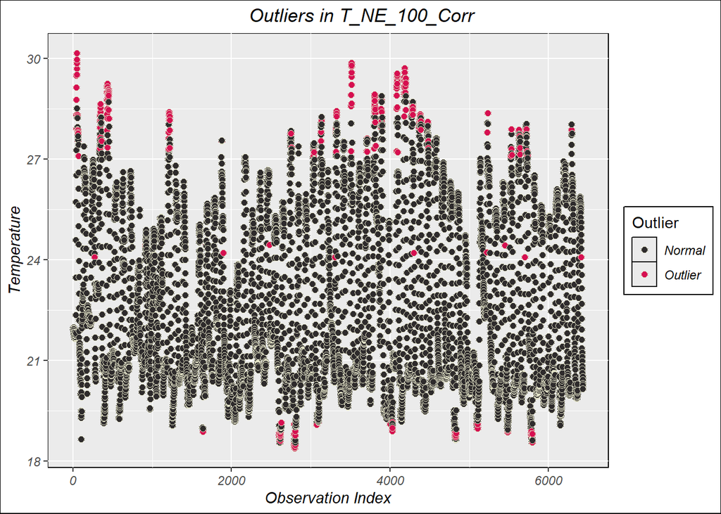

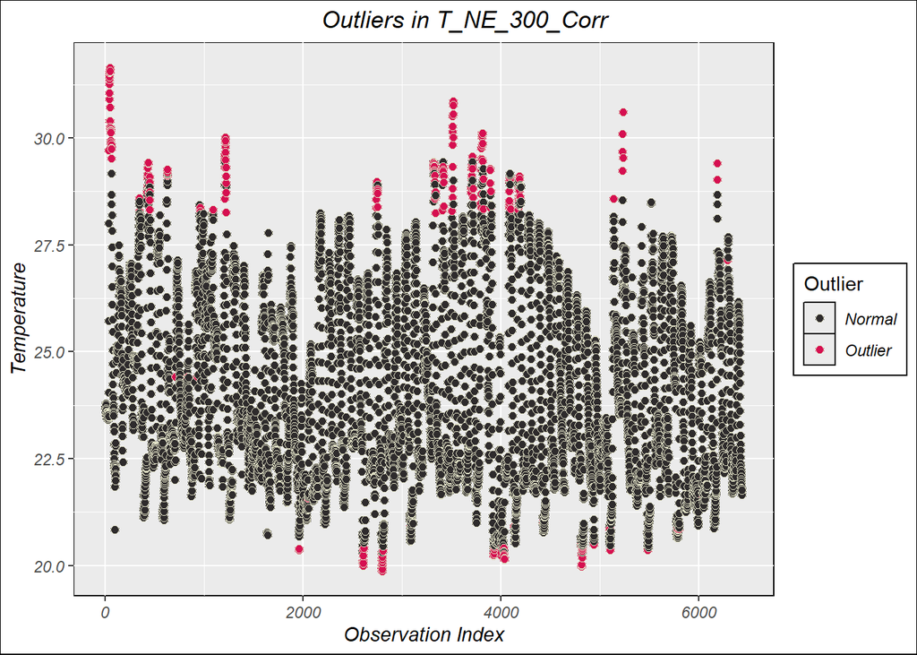

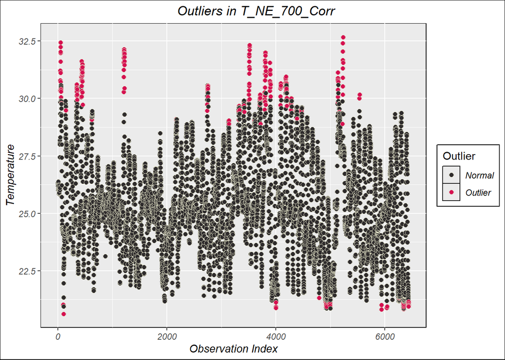

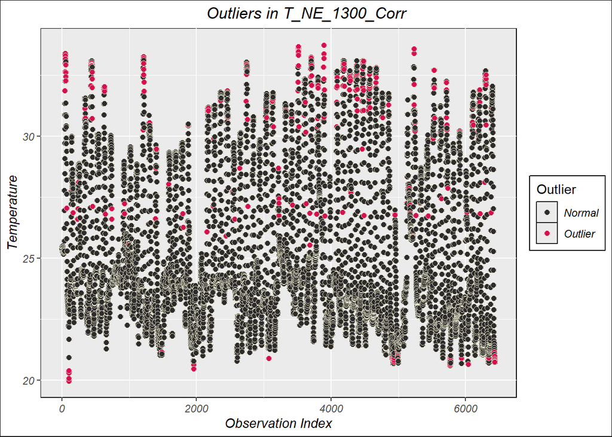

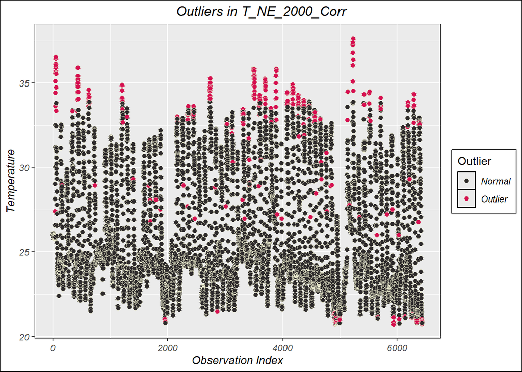

```r
# Select the corrected columns starting with "T_NE"
temp_columns <- grep("^T_NE", names(ne_temp_2020), value = TRUE)

# Considering values of those columns
temp_df <- ne_temp_2020[, temp_columns]

# Function to detect outliers using KNN
detect_outlier_temp <- function(data) {

  # Compute KNN distances
  knn_dist_temp <- knn.dist(as.matrix(data), k = 6)

  # Calculate the 95th percentile of distances for each point
  quantile_dist_temp <- apply(knn_dist_temp, 1, function(x) quantile(x, 0.95))

  # Identify outliers as points where the distance exceeds the 95th percentile
  outlier_temp <- quantile_dist_temp > quantile(quantile_dist_temp, 0.95)

  return(outlier_temp)
}

# Initialize a list to store outlier results
outlier_results <- list()

# Detect outliers for each column
for (col in temp_columns) {
  column_data <- temp_df[[col]]
  outliers <- detect_outlier_temp(column_data)
  outlier_results[[col]] <- outliers
}

# Visualize outliers for each column
for (col in temp_columns) {
  # Create a data frame for plotting
  plot_data <- data.frame(
    Index = 1:nrow(temp_df),
    Value = temp_df[[col]],
    Outlier = outlier_results[[col]]
  )

  # Plot the data with outliers highlighted
  p1 <- ggplot(plot_data, aes(x = Index, y = Value, fill = Outlier)) +
    geom_point(size = 2, shape = 21, stroke = 0.5, color = "#e0e0c5") +
    scale_fill_manual(values = c("#2e2b2c", "#d60f51"), labels = c("Normal", "Outlier")) +
    labs(title = paste("Outliers in", col),
         x = "Observation Index",
         y = "Temperature") +
    theme_gray()+
    theme(
      plot.background = element_rect(color = "black"),
      panel.background = element_rect(color = "black"),
      plot.title = element_text(face = "italic", hjust = 0.6),
      axis.title = element_text(face = "italic"),
      axis.text = element_text(face = 'italic'),
      legend.background = element_rect(color = "black"),
      legend.key = element_rect(color = 'black'),
      legend.text = element_text(face = 'italic')


    )

  print(p1)
}
```

#Each day value according to the zone wise

### South Tower Data Processing Summary

1. Imported 15-minute resolution humidity/temperature data from South Tower sensors (100m–2000m elevations).
2. Preprocessed by removing null columns, standardizing headers, and preserving raw data copies.
3. Structured datasets with consistent columns: `DateTime` + 5 elevation-specific sensor readings.
4. Verified data integrity—no missing values detected during initial inspection.
5. Prepared for calibration and integration with other tower datasets for microclimate analysis.

```r
#Importing the other towers relative humidity and temperature for south, northwest and the mountain tower.

humidity2 <- read.csv('data/S_Tower_Relative humidity.csv', skip = 4, header = FALSE)

#taking a copy of the dataframe
s_humid <- data.frame(humidity2)

# Taking off the null column the V7 by selecting 6 columns only
s_humid <- s_humid[, 1:6]


# Reassigning the column names as needed
colnames(s_humid) <- c("DateTime", "TRF_STower_100_HMP45", "TRF_STower_300_HMP45","TRF_STower_700_HMP45","TRF_STower_1300_HMP45","TRF_SETower_2000_HMP45")


#Loading the file
temperature2 <- read.csv('C:/Users/ual-laptop/Desktop/NE/S_Tower_Temperature.csv', skip = 4, header = FALSE)

#Copying the dataframe
s_temp <- data.frame(temperature2)

# Taking off the null column the V7 by selecting 6 columns only
s_temp <- s_temp[, 1:6]

# Reassigning the column names as needed
colnames(s_temp) <- c("DateTime", "TRF_STower_100_HMP45", "TRF_STower_300_HMP45","TRF_STower_700_HMP45","TRF_STower_1300_HMP45","TRF_SETower_2000_HMP45")
```

### NORTH WEST - RELATIVE HUMIDITY AND TEMPERATURE

```r
#Loading the file
temperature3 <- read.csv('data/NW_Tower_Temperature.csv', skip = 4, header = FALSE)

#Copying the file
nw_temp <- data.frame(temperature3)

# Taking off the null column the V6 by selecting 6 columns only
nw_temp <- nw_temp[, 1:5]

# Reassigning the column names as needed
colnames(nw_temp) <- c("DateTime", "TRF_NWTower_100_HMP45", "TRF_NWTower_300_HMP45","TRF_NWTower_700_HMP45","TRF_NWTower_1300_HMP45")

#Loading the file
humidity3 <- read.csv('data/NW_Tower_Relative humidity.csv', skip = 4, header = FALSE )

#Copying the file
nw_humid <- data.frame(humidity3)

# Taking off the null column the V6 by selecting 6 columns only
nw_humid <- nw_humid[, 1:5]

# Reassigning the column names as needed
colnames(nw_humid) <- c("DateTime", "TRF_NWTower_100_HMP45", "TRF_NWTower_300_HMP45","TRF_NWTower_700_HMP45","TRF_NWTower_1300_HMP45")
```

### MOUNTAIN TOWER - TEMPERATURE AND RELATIVE HUMIDITY

```r
#loading the file
temperature4 <- read.csv('C:/Users/ual-laptop/Desktop/NE/Mtn_Tower_Temperature.csv', skip = 4, header = FALSE)

#Taking a copy of the file
mtn_temp <- data.frame(temperature4)


# Taking off the null column the V6 by selecting 6 columns only
mtn_temp <- mtn_temp[, 1:5]

# Reassigning the column names as needed
colnames(mtn_temp) <- c("DateTime", "TRF_MTNTower_100_HMP45", "TRF_MTNTower_300_HMP45","TRF_MTNTower_700_HMP45","TRF_MTNTower_1300_HMP45")


#Loading the file
humidity4 <- read.csv('C:/Users/ual-laptop/Desktop/NE/Mtn_Tower_Relative humidity.csv', skip = 4, header = FALSE )

#Copying the dataframe
mtn_humid <- data.frame(humidity4)


# Taking off the null column the V6 by selecting 6 columns only
mtn_humid <- mtn_humid[, 1:5]

# Reassigning the column names as needed
colnames(mtn_humid) <- c("DateTime", "TRF_MTNTower_100_HMP45", "TRF_MTNTower_300_HMP45","TRF_MTNTower_700_HMP45","TRF_MTNTower_1300_HMP45")
```

### Data Quality Validation

This code systematically checks for missing values across humidity and temperature datasets from three towers (Northwest, Mountain, South) using a custom `check_na_counts` function. It calculates and displays NA counts per column for all six datasets, enabling consistent data gap identification across the sensor network. The automated process ensures uniform quality assessment while maintaining clear dataset labeling.

```r
# Function to check for NA values in each column
check_na_counts <- function(df, name) {
  na_counts <- colSums(is.na(df))
  cat(paste("NA counts for", name, "\n"))
  print(na_counts)

  return(na_counts)
}

# Applying functions to all datasets
na_nw_humid <- check_na_counts(nw_humid, "North West Humidity")
```

```
## NA counts for North West Humidity
##               DateTime  TRF_NWTower_100_HMP45  TRF_NWTower_300_HMP45
##                      0                      0                      0
##  TRF_NWTower_700_HMP45 TRF_NWTower_1300_HMP45
##                      0                      0
```

```r
na_nw_temp <- check_na_counts(nw_temp, "North West Temperature")
```

```
## NA counts for North West Temperature
##               DateTime  TRF_NWTower_100_HMP45  TRF_NWTower_300_HMP45
##                      0                      0                      0
##  TRF_NWTower_700_HMP45 TRF_NWTower_1300_HMP45
##                      0                      0
```

```r
na_mtn_humid <- check_na_counts(mtn_humid, "Mountain Humidity")
```

```
## NA counts for Mountain Humidity
##                DateTime  TRF_MTNTower_100_HMP45  TRF_MTNTower_300_HMP45
##                       0                       0                       0
##  TRF_MTNTower_700_HMP45 TRF_MTNTower_1300_HMP45
##                       0                       0
```

```r
na_mtn_temp <- check_na_counts(mtn_temp, "Mountain Temperature")
```

```
## NA counts for Mountain Temperature
##                DateTime  TRF_MTNTower_100_HMP45  TRF_MTNTower_300_HMP45
##                       0                       0                       0
##  TRF_MTNTower_700_HMP45 TRF_MTNTower_1300_HMP45
##                       0                       0
```

```r
na_s_humid <- check_na_counts(s_humid, "Southern Humidity")
```

```
## NA counts for Southern Humidity
##               DateTime   TRF_STower_100_HMP45   TRF_STower_300_HMP45
##                      0                      0                      0
##   TRF_STower_700_HMP45  TRF_STower_1300_HMP45 TRF_SETower_2000_HMP45
##                      0                      0                      0
```

```r
na_s_temp <- check_na_counts(s_temp, "Southern Temperature")
```

```
## NA counts for Southern Temperature
##               DateTime   TRF_STower_100_HMP45   TRF_STower_300_HMP45
##                      0                      0                      0
##   TRF_STower_700_HMP45  TRF_STower_1300_HMP45 TRF_SETower_2000_HMP45
##                      0                      0                      0
```

### Data Completeness Check

This code validates 2020 sensor data completeness across all towers by: Filtering to 2020 data and counting daily readings (expected: 96/day) Identifying dates with incomplete measurements. Processing both humidity and temperature data from three towers (NW, Mountain, South). Returning cleaned 2020 datasets while reporting gaps.

```r
# Function to filter and find missing readings

process_data <- function(tower, name) {
  tower_2020 <- tower |> filter(year(DateTime) == 2020)
  readings_per_day <- tower_2020 |> group_by(Date = date(DateTime)) |> summarize(Readings = n())
  missing_days <- readings_per_day |> filter(Readings != 96)

  cat(paste("Missing dates on", name, "\n"))
  print(missing_days)

  return(tower_2020)
}

# Applying the function to all datasets
nw_humid_2020 <- process_data(nw_humid, "NW Humidity")
```

```
## Missing dates on NW Humidity
## # A tibble: 0 × 2
## # ℹ 2 variables: Date <date>, Readings <int>
```

```r
nw_temp_2020 <- process_data(nw_temp, "NW Temperature")
```

```
## Missing dates on NW Temperature
## # A tibble: 0 × 2
## # ℹ 2 variables: Date <date>, Readings <int>
```

```r
mtn_humid_2020 <- process_data(mtn_humid, "Mountain Humidity")
```

```
## Missing dates on Mountain Humidity
## # A tibble: 0 × 2
## # ℹ 2 variables: Date <date>, Readings <int>
```

```r
mtn_temp_2020 <- process_data(mtn_temp, "Mountain Temperature")
```

```
## Missing dates on Mountain Temperature
## # A tibble: 0 × 2
## # ℹ 2 variables: Date <date>, Readings <int>
```

```r
s_humid_2020 <- process_data(s_humid, "Southern Humidity")
```

```
## Missing dates on Southern Humidity
## # A tibble: 0 × 2
## # ℹ 2 variables: Date <date>, Readings <int>
```

```r
s_temp_2020 <- process_data(s_temp, "Southern Temperature")
```

```
## Missing dates on Southern Temperature
## # A tibble: 0 × 2
## # ℹ 2 variables: Date <date>, Readings <int>
```

### Calibrations of temperature and relative humidity sensors for the South Tower, North West Tower, and Mountain Tower.

### Conducting temperature and relative humidity sensor calibrations for the Mountain Tower.

```r
#Temperature: Applied elevation-specific correction formulas to raw sensor data
mtn_temp_2020 <- mtn_temp_2020 %>%
  mutate(
    T_MTN_100_Corr  = TRF_MTNTower_100_HMP45,
    T_MTN_300_Corr  = TRF_MTNTower_300_HMP45 * 0.9383 + 1.67,
    T_MTN_700_Corr  = TRF_MTNTower_700_HMP45 * 1.129 - 2.4,
    T_MTN_1300_Corr = TRF_MTNTower_1300_HMP45 * 1.004 - 0.02
  )

# Relative Humidity: Corrected raw values with standardized transformation equation
mtn_humid_2020 <- mtn_humid_2020 %>%
  mutate(
    RH_MTN_100_Corr  = TRF_MTNTower_100_HMP45,
    RH_MTN_300_Corr  = TRF_MTNTower_300_HMP45 * 0.8975 + 12.2,
    RH_MTN_700_Corr  = TRF_MTNTower_700_HMP45 * 0.863 + 16.2,
    RH_MTN_1300_Corr = TRF_MTNTower_1300_HMP45 * 1.008 + 1.1
  )
```

#### Conducting temperature and relative humidity sensor calibrations for the North west Tower.

```r
#Temperature: Applied elevation-specific correction formulas to raw sensor data
nw_temp_2020 <- nw_temp_2020 %>%
  mutate(
    T_NW_100_Corr  = TRF_NWTower_100_HMP45 * 0.9922 + 0.6,
    T_NW_300_Corr  = TRF_NWTower_300_HMP45 * 1.005 - 0.17,
    T_NW_700_Corr  = TRF_NWTower_700_HMP45 * 1.007 - 0.14,
    T_NW_1300_Corr = TRF_NWTower_1300_HMP45 * 0.9801 + 0.54
  )

#Relative Humidity: Corrected raw values with standardized transformation equation
nw_humid_2020 <- nw_humid_2020 %>%
  mutate(
    RH_NW_100_Corr  = TRF_NWTower_100_HMP45 * 0.9756 - 1.2,
    RH_NW_300_Corr  = TRF_NWTower_300_HMP45 * 0.9882 - 1.6,
    RH_NW_700_Corr  = TRF_NWTower_700_HMP45 * 0.9895 + 1.1,
    RH_NW_1300_Corr = TRF_NWTower_1300_HMP45 * 1.012 + 1.334
  )
```

#### Conducting temperature and relative humidity sensor calibrations for the South Tower.

```r
#Temperature: Applied elevation-specific correction formulas to raw sensor data
s_temp_2020 <- s_temp_2020 %>%
  mutate(
    T_S_100_Corr  = TRF_STower_100_HMP45 * 1.041 + 0.08,
    T_S_300_Corr  = TRF_STower_300_HMP45 * 1.026 - 0.04,
    T_S_700_Corr  = TRF_STower_700_HMP45 * 1.037 - 0.15,
    T_S_1300_Corr = TRF_STower_1300_HMP45 * 1.059 - 0.31,
    T_S_2000_Corr = TRF_SETower_2000_HMP45  # No calibration needed
  )

#Relative Humidity: Corrected raw values with standardized transformation equation
s_humid_2020 <- s_humid_2020 %>%
  mutate(
    RH_S_100_Corr  = TRF_STower_100_HMP45 * 0.996 + 0.1,
    RH_S_300_Corr  = TRF_STower_300_HMP45 * 1.04 - 2.4,
    RH_S_700_Corr  = TRF_STower_700_HMP45 * 1.053 + 1.1,
    RH_S_1300_Corr = TRF_STower_1300_HMP45 * 0.9499 + 7.4,
    RH_S_2000_Corr = TRF_SETower_2000_HMP45  # No calibration needed
  )
```

### Zone wise calibrations

#### Zone -1

Calculates daily mean temperature and relative humidity for Zone 1 (1m-3m elevation) by combining calibrated South Tower and NE Tower sensor data. Outputs preview of aggregated daily values showing:

Zone_1_Temp_Avg: Mean daily temperature across 100m/300m sensors Zone_1_RH_Avg: Mean daily relative humidity across 100m/300m sensors

```r
zone1_data <- s_temp_2020 |>
  select(DateTime, T_S_100_Corr, T_S_300_Corr) %>%
  left_join(
    s_humid_2020 %>%
      select(DateTime, RH_S_100_Corr, RH_S_300_Corr),
    by = "DateTime"
  ) %>%
  left_join(
    ne_temp_2020 %>%
      select(DateTime, T_NE_100_Corr, T_NE_300_Corr),
    by = "DateTime"
  ) %>%
  left_join(
    ne_humid_2020 %>%
      select(DateTime, RH_NE_100_Corr, RH_NE_300_Corr),
    by = "DateTime"
  ) %>%
  mutate(Date = as.Date(DateTime, format = "%Y/%m/%d %H:%M")) %>%
  group_by(Date) %>%
  summarize(
    Zone_1_Temp_Avg = mean(c(T_S_100_Corr, T_S_300_Corr, T_NE_100_Corr, T_NE_300_Corr), na.rm = TRUE),
    Zone_1_RH_Avg = mean(c(RH_S_100_Corr, RH_S_300_Corr, RH_NE_100_Corr, RH_NE_300_Corr), na.rm = TRUE),
    .groups = "drop"
  )

# View result
print("Zone 1 Data:")
```

```
## [1] "Zone 1 Data:"
```

```r
print(head(zone1_data))
```

```
## # A tibble: 6 × 3
##   Date       Zone_1_Temp_Avg Zone_1_RH_Avg
##   <date>               <dbl>         <dbl>
## 1 2020-01-01            25.3          67.4
## 2 2020-01-02            24.5          73.9
## 3 2020-01-03            25.0          63.5
## 4 2020-01-04            25.5          62.8
## 5 2020-01-05            24.6          79.3
## 6 2020-01-06            24.1          72.8
```

### Zone-2

Zone_2_Temp_Avg: Mean temperature (100m-1300m sensors) Zone_2_RH_Avg: Mean relative humidity (100m-1300m sensors)

```r
# Zone 2 calculation (Temperature and Humidity from NW (100, 300, 700), South (700, 1300), Northeast (700,1300)) and Mountain Tower (100,300)

zone2_data <- nw_temp_2020 %>%
  select(DateTime, T_NW_100_Corr, T_NW_300_Corr, T_NW_700_Corr) %>%
  left_join(
    s_temp_2020 %>%
      select(DateTime, T_S_700_Corr, T_S_1300_Corr),
    by = "DateTime"
  ) %>%
  left_join(
    ne_temp_2020 %>%
      select(DateTime, T_NE_700_Corr, T_NE_1300_Corr),
    by = "DateTime"
  ) %>%
  left_join(
    mtn_temp_2020 %>%
      select(DateTime, T_MTN_100_Corr, T_MTN_300_Corr),
    by = "DateTime"
  ) %>%
  left_join(
    nw_humid_2020 %>%
      select(DateTime, RH_NW_100_Corr, RH_NW_300_Corr, RH_NW_700_Corr),
    by = "DateTime"
  ) %>%
  left_join(
    s_humid_2020 %>%
      select(DateTime, RH_S_700_Corr, RH_S_1300_Corr),
    by = "DateTime"
  ) %>%
  left_join(
    ne_humid_2020 %>%
      select(DateTime, RH_NE_700_Corr, RH_NE_1300_Corr),
    by = "DateTime"
  ) %>%
  left_join(
    mtn_humid_2020 %>%
      select(DateTime, RH_MTN_100_Corr, RH_MTN_300_Corr),
    by = "DateTime"
  ) %>%
  mutate(Date = as.Date(DateTime, format = "%Y/%m/%d %H:%M")) %>%
  group_by(Date) %>%
  summarize(
    Zone_2_Temp_Avg = mean(c(
      T_NW_100_Corr, T_NW_300_Corr, T_NW_700_Corr,
      T_S_700_Corr, T_S_1300_Corr,
      T_NE_700_Corr, T_NE_1300_Corr,
      T_MTN_100_Corr, T_MTN_300_Corr
    ), na.rm = TRUE),

    Zone_2_RH_Avg = mean(c(
      RH_NW_100_Corr, RH_NW_300_Corr, RH_NW_700_Corr,
      RH_S_700_Corr, RH_S_1300_Corr,
      RH_NE_700_Corr, RH_NE_1300_Corr,
      RH_MTN_100_Corr, RH_MTN_300_Corr
    ), na.rm = TRUE),
    .groups = "drop"
  )

# View result
print("Zone 2 Data:")
```

```
## [1] "Zone 2 Data:"
```

```r
print(head(zone2_data))
```

```
## # A tibble: 6 × 3
##   Date       Zone_2_Temp_Avg Zone_2_RH_Avg
##   <date>               <dbl>         <dbl>
## 1 2020-01-01            27.0          62.7
## 2 2020-01-02            25.3          72.2
## 3 2020-01-03            25.7          61.1
## 4 2020-01-04            26.3          60.6
## 5 2020-01-05            26.3          74.7
## 6 2020-01-06            25.9          68.0
```

### Zone - 3

```r
# Zone 3 calculation (Temperature and Humidity from South (2000), NW (1300), Mtn (700, 1300), Northeast (2000))

zone3_data <- s_temp_2020 %>%
  select(DateTime, T_S_2000_Corr) %>%
  left_join(
    nw_temp_2020 %>%
      select(DateTime, T_NW_1300_Corr),
    by = "DateTime"
  ) %>%
  left_join(
    mtn_temp_2020 %>%
      select(DateTime, T_MTN_700_Corr, T_MTN_1300_Corr),
    by = "DateTime"
  ) %>%
  left_join(
    ne_temp_2020 %>%
      select(DateTime, T_NE_2000_Corr),
    by = "DateTime"
  ) %>%
  left_join(
    s_humid_2020 %>%
      select(DateTime, RH_S_2000_Corr),
    by = "DateTime"
  ) %>%
  left_join(
    nw_humid_2020 %>%
      select(DateTime, RH_NW_1300_Corr),
    by = "DateTime"
  ) %>%
  left_join(
    mtn_humid_2020 %>%
      select(DateTime, RH_MTN_700_Corr, RH_MTN_1300_Corr),
    by = "DateTime"
  ) %>%
  left_join(
    ne_humid_2020 %>%
      select(DateTime, RH_NE_2000_Corr),
    by = "DateTime"
  ) %>%
  mutate(Date = as.Date(DateTime, format = "%Y/%m/%d %H:%M")) %>%
  group_by(Date) %>%
  summarize(
    Zone_3_Temp_Avg = mean(c(
      T_S_2000_Corr,
      T_NW_1300_Corr,
      T_MTN_700_Corr, T_MTN_1300_Corr,
      T_NE_2000_Corr
    ), na.rm = TRUE),

    Zone_3_RH_Avg = mean(c(
      RH_S_2000_Corr,
      RH_NW_1300_Corr,
      RH_MTN_700_Corr, RH_MTN_1300_Corr,
      RH_NE_2000_Corr
    ), na.rm = TRUE),

    .groups = "drop"
  )

# View result
print("Zone 3 Data:")
```

```
## [1] "Zone 3 Data:"
```

```r
print(head(zone3_data))
```

```
## # A tibble: 6 × 3
##   Date       Zone_3_Temp_Avg Zone_3_RH_Avg
##   <date>               <dbl>         <dbl>
## 1 2020-01-01            28.1          60.3
## 2 2020-01-02            26.5          68.6
## 3 2020-01-03            26.6          58.9
## 4 2020-01-04            27.4          58.5
## 5 2020-01-05            27.8          70.5
## 6 2020-01-06            27.2          65.1
```

## Zone wise calculation of no of moles

```r
#Loading the files for the zone1,zone2,zone3 of the carbondioxide files
co2_zone1 <- read.csv('data/SCADA_LOLNDCO2_1M.csv', skip = 2)
co2_zone2 <- read.csv('data/SCADA_LOLNDCO2_13M.csv', skip = 2)

#Already loaded the zone 3 for the carbondioxide
#co2_zone3
```

```r
#Checking on the missing the value and fetching the mean of the carbondioxide for the year 2020  not considering the null values.

# Check for missing values in each column
colSums(is.na(co2_zone1))
```

```
##             ID      TIMESTAMP     TRENDFLAGS         STATUS          VALUE
##              0              0             14             14             14
## TRENDFLAGS_TAG     STATUS_TAG
##              0              0
```

```r
# Check for missing values in each column
colSums(is.na(co2_zone2))
```

```
##             ID      TIMESTAMP     TRENDFLAGS         STATUS          VALUE
##              0              0             14             14             14
## TRENDFLAGS_TAG     STATUS_TAG
##              0              0
```

```r
# Check for missing values in each column
colSums(is.na(co2_zone3))
```

```
##             ID      TIMESTAMP     TRENDFLAGS         STATUS          VALUE
##              0              0              0              0              0
## TRENDFLAGS_TAG     STATUS_TAG     Is_Outlier
##              0              0              0
```

### Handling Missing Carbondioxide Data Across Zones

Zones 1 and 2 had 14 missing carbondioxide values, which were addressed using linear interpolation to fill the gaps. Zone 3 required no further action, as interpolation had already been performed.

```r
#Filling out the value's missing value with the interpolation
co2_zone1 <- co2_zone1 |> mutate(VALUE = na.approx(VALUE, na.rm = FALSE))
co2_zone2 <- co2_zone2 |> mutate(VALUE = na.approx(VALUE, na.rm = FALSE))

# Check for missing values in each column
colSums(is.na(co2_zone1))
```

```
##             ID      TIMESTAMP     TRENDFLAGS         STATUS          VALUE
##              0              0             14             14              0
## TRENDFLAGS_TAG     STATUS_TAG
##              0              0
```

```r
colSums(is.na(co2_zone2))
```

```
##             ID      TIMESTAMP     TRENDFLAGS         STATUS          VALUE
##              0              0             14             14              0
## TRENDFLAGS_TAG     STATUS_TAG
##              0              0
```

```r
# Convert TIMESTAMP to a datetime format
co2_zone1 <- co2_zone1 %>% mutate(TIMESTAMP = as.POSIXct(TIMESTAMP, format = "%Y/%m/%d %H:%M:%S"))|> filter(year(TIMESTAMP) == 2020)
co2_zone2 <- co2_zone2 %>% mutate(TIMESTAMP = as.POSIXct(TIMESTAMP, format = "%Y/%m/%d %H:%M:%S"))|> filter(year(TIMESTAMP) == 2020)


##  Counting the number as the readings takes place for every 15 min
readings_per_day_z1 <- co2_zone1 |> group_by(Date = date(TIMESTAMP)) %>% summarize(Readings = n())
readings_per_day_z2 <- co2_zone2 |> group_by(Date = date(TIMESTAMP)) %>% summarize(Readings = n())

##Missing date readings
missing_day_z1 <- readings_per_day_z1 |> filter(Readings != 96)
missing_day_z2 <- readings_per_day_z2 |> filter(Readings != 96)

cat("Missing dates of zone-1")
```

```
## Missing dates of zone-1
```

```r
print(missing_day_z1)
```

```
## # A tibble: 1 × 2
##   Date       Readings
##   <date>        <int>
## 1 2020-02-25       95
```

```r
cat("Missing dates of zone-2")
```

```
## Missing dates of zone-2
```

```r
print(missing_day_z2)
```

```
## # A tibble: 1 × 2
##   Date       Readings
##   <date>        <int>
## 1 2020-02-25       95
```

### Zone-wise CO₂ Concentration Analysis (2020)

```r
# Calculate the daily average carbondioxide concentration for Zone 1 during the year 2020.
avg_co2_zone1 <- co2_zone1 |>
  mutate(Date = as.Date(TIMESTAMP),
         Year = year(Date)) |>
  filter(Year == 2020) |>
  summarize(mean_co2 = mean(VALUE, na.rm = TRUE))|>
  pull(mean_co2)

# Calculate the daily average carbondioxide concentration for Zone 2 during the year 2020.
avg_co2_zone2 <- co2_zone2 |>
  mutate(Date = as.Date(TIMESTAMP),
         Year = year(Date)) |>
  filter(Year == 2020) |>
  summarize(mean_co2 = mean(VALUE, na.rm = TRUE))|>
  pull(mean_co2)


# Calculate the daily average Carbondioxide concentration for Zone 3 during the year 2020.
avg_co2_zone3 <- co2_zone3 |>
  mutate(Date = as.Date(TIMESTAMP),
         Year = year(Date)) |>
  filter(Year == 2020) |>
  summarize(mean_co2 = mean(VALUE, na.rm = TRUE))|>
  pull(mean_co2)
```

### Checking if each day has 96 readings as we deal with co2_zone_3 values, and have inserted a row as there is a missing value on feb 25 at 9:30 because of some technical problems and it was restarted later.

```r
# Create new row for missing timestamp for the zone_1 carbondioxide
missingrow_z1 <- data.frame(ID = "0000",
                          TIMESTAMP = as.POSIXct("2020-02-25 09:30:00"),
                          VALUE = avg_co2_zone1,
                          TRENDFLAGS = 0,
                          STATUS = 0,
                          TRENDFLAGS_TAG = "{}",
                          STATUS_TAG = "{ok}"

)

# Insert into dataset and arranging the time stamp according to the time.
co2_zone1 <- co2_zone1 |>
  bind_rows(missingrow_z1) |>
  arrange(TIMESTAMP)


# Create new row for missing timestamp for the zone_2 carbondioxide
missingrow_z2 <- data.frame(ID = "0000",
                          TIMESTAMP = as.POSIXct("2020-02-25 09:30:00"),
                          VALUE = avg_co2_zone2,
                          TRENDFLAGS = 0,
                          STATUS = 0,
                          TRENDFLAGS_TAG = "{}",
                          STATUS_TAG = "{ok}"

)

# Insert into dataset and arranging the time stamp according to the time.
co2_zone2 <- co2_zone2 |>
  bind_rows(missingrow_z2) |>
  arrange(TIMESTAMP)
```

### Zone-wise Temperature Averaging and Conversion (2020)

Calculated the average temperature for each zone in 2020 and converted the values from Celsius to Kelvin by adding 273.15.

```r
#Averaging the temperature zonewise - 2020 and converting from celsius to kelvin by adding 273.15

temp_zone1 <- mean(zone1_data$Zone_1_Temp_Avg) + 273.15
temp_zone2 <- mean(zone2_data$Zone_2_Temp_Avg) + 273.15
temp_zone3 <- mean(zone3_data$Zone_3_Temp_Avg) + 273.15
```

#Calculating carbondioxide moles per zone

###### P - Pressure (Pa) from 884 mbar, V - Rainforest volume (m³) ,R- Gas constant (m³·Pa·K⁻¹·mol⁻¹) and Zone 1/2/3 volume fraction.

```r
# Constants
P <- 88400
V <- 26700
R <- 8.31446
vol_fracs <- c(0.304, 0.588, 0.108)


# Function to compute Co2 moles for a zone
co2_moles <- function(avg_co2_ppm, temp_k, vol_frac) {
  n_air <- (P * V) / (R * temp_k)
  n_co2 <- n_air * (avg_co2_ppm / 1e6) * vol_frac
  return(n_co2)
}


# Add daily CO2 moles to each zone's data
zone1_moles <- co2_moles(avg_co2_zone1,temp_zone1, vol_fracs[1])
zone2_moles <- co2_moles(avg_co2_zone2,temp_zone2, vol_fracs[2])
zone3_moles <- co2_moles(avg_co2_zone3,temp_zone3, vol_fracs[3])

print(paste("zone1 moles of co2:", zone1_moles, "zone-2 moles of co2:", zone2_moles, "zone-3 moles of co2:", zone3_moles))
```

```
## [1] "zone1 moles of co2: 125.448091658942 zone-2 moles of co2: 232.441088719022 zone-3 moles of co2: 43.782705788632"
```

### Calculating daily co2 moles and it’s difference

To analyze daily carbondioxide dynamics across the rainforest zones, we first process the raw sensor data to calculate daily average CO₂ concentrations for each vertical zone (1m, 13m, and 27m) throughout 2020. This involves creating three separate datasets (co2_z1, co2_z2, co2_z3) where we: (1) convert timestamps to dates, (2) filter for 2020 measurements, and (3) compute daily mean CO₂ values while handling any missing data. These daily CO₂ averages are then joined to their corresponding zone datasets (zone1_data, zone2_data, zone3_data) which already contain the daily temperature and humidity measurements.

Finally, to track daily CO₂ fluctuations, we compute the difference iN CO₂ moles between consecutive days for each zone, storing these values in new co2_diff columns. This sequential differencing (day 2 - day 1, day 3 - day 2, etc.) reveals the net daily changes in CO₂ quantities at each canopy level, providing insights into vertical carbon flux patterns throughout the observation period. The complete dataset now enables both daily snapshots and trend analysis of the rainforest’s carbon dynamics across its vertical profile.

```r
# Creating a new dataframe co2_z1 for each day's carbondioxide value
co2_z1 <- co2_zone1|>
  mutate(Date = as.Date(TIMESTAMP),
         Year = year(Date)) |>
  filter(Year == 2020) |>
  group_by(Date) |>
  summarize(carbondioxide_z1 = mean(VALUE, na.rm = TRUE))


# Creating a new dataframe co2_z2 for each day's carbondioxide value
co2_z2 <- co2_zone2 |>
  mutate(Date = as.Date(TIMESTAMP),Year = year(Date)) |>
  filter(Year == 2020) |>
  group_by(Date) |>
  summarize(carbondioxide_z2 = mean(VALUE, na.rm = TRUE))


co2_z3 <- co2_zone3 |>
  mutate( Date = as.Date(TIMESTAMP),Year = year(Date)) |>
  filter(TIMESTAMP >= "2020/01/01 00:00:00") |>
  group_by(Date)|>
  summarize(carbondioxide_z3 = mean(VALUE, na.rm = TRUE))



# Adding the carbondioxide value from co2_z1 dataframe to the zone1_data dataframe
zone1_data <- zone1_data |>
  left_join(co2_z1, by = "Date")



# Adding the carbondioxide value from co2_z2 dataframe to the zone2_data dataframe
zone2_data <- zone2_data |>
  left_join(co2_z2, by = "Date")


# Adding the carbondioxide value from co2_z1 dataframe to the zone1_data dataframe
zone3_data <- zone3_data |>
  left_join(co2_z3, by = "Date")
```

```r
#Adding temp with 273K to convert it to kelvin
zone1_data$Zone_1_Temp_Avg <- (zone1_data$Zone_1_Temp_Avg) + 273.15
zone2_data$Zone_2_Temp_Avg <- (zone2_data$Zone_2_Temp_Avg) + 273.15
zone3_data$Zone_3_Temp_Avg <- (zone3_data$Zone_3_Temp_Avg) + 273.15



# Creating a new column named moles in the zone1_data
zone1_data <- zone1_data |>
  mutate(moles = co2_moles(carbondioxide_z1, Zone_1_Temp_Avg, vol_fracs[1]))

# Creating a new column named moles in the zone2_data
zone2_data <- zone2_data |>
  mutate(moles = co2_moles(carbondioxide_z2, Zone_2_Temp_Avg, vol_fracs[2]))

# Creating a new column named moles in the zone3_data
zone3_data <- zone3_data |>
  mutate(moles = co2_moles(carbondioxide_z3, Zone_3_Temp_Avg, vol_fracs[3]))



#Zone 1,2,3 difference of moles calculated between consective dates
zone1_data$Zone_1_CO2_Diff <- c(NA, diff(zone1_data$moles))
zone2_data$Zone_2_CO2_Diff <- c(NA, diff(zone2_data$moles))
zone3_data$Zone_3_CO2_Diff <- c(NA, diff(zone3_data$moles))
```

```r
## Every 15 min no of moles and the difference between present and the next 15 min.
zone1_minute_data <- co2_zone1 |> mutate(TIMESTAMP = as.POSIXct(TIMESTAMP, format = "%Y/%m/%d %H:%M:%S"))|> filter(year(TIMESTAMP) == 2020)


zone2_minute_data <- co2_zone2 |> mutate(TIMESTAMP = as.POSIXct(TIMESTAMP, format = "%Y/%m/%d %H:%M:%S"))|> filter(year(TIMESTAMP) == 2020)

zone3_minute_data <- co2_zone3 |> mutate(TIMESTAMP = as.POSIXct(TIMESTAMP, format = "%Y/%m/%d %H:%M:%S"))|> filter(year(TIMESTAMP) == 2020)
```

```r
# Prepare Zone 1 temp and humidity
zone1_temp_humid <- s_temp_2020 %>%
  select(DateTime, T_S_100_Corr, T_S_300_Corr) %>%
  left_join(
    ne_temp_2020 %>%
      select(DateTime, T_NE_100_Corr, T_NE_300_Corr),
    by = "DateTime"
  ) %>%
  left_join(
    s_humid_2020 %>%
      select(DateTime, RH_S_100_Corr, RH_S_300_Corr),
    by = "DateTime"
  ) %>%
  left_join(
    ne_humid_2020 %>%
      select(DateTime, RH_NE_100_Corr, RH_NE_300_Corr),
    by = "DateTime"
  ) %>%
  mutate(
    TIMESTAMP = as.POSIXct(DateTime, format = "%Y/%m/%d %H:%M"),
    # Compute average temp and RH
    Temp_Avg = rowMeans(select(., T_S_100_Corr, T_S_300_Corr, T_NE_100_Corr, T_NE_300_Corr), na.rm = TRUE),
    RH_Avg = rowMeans(select(., RH_S_100_Corr, RH_S_300_Corr, RH_NE_100_Corr, RH_NE_300_Corr), na.rm = TRUE)
  ) %>%
  select(TIMESTAMP, Temp_Avg, RH_Avg)
# Prepare Zone 2 CO₂ minute data
zone2_minute_data <- co2_zone2 %>%
  mutate(TIMESTAMP = as.POSIXct(TIMESTAMP, format = "%Y/%m/%d %H:%M:%S")) %>%
  filter(year(TIMESTAMP) == 2020)
```

```r
# Prepare Zone 2 temperature and humidity
zone2_temp_humid <- nw_temp_2020 %>%
  select(DateTime, T_NW_100_Corr, T_NW_300_Corr, T_NW_700_Corr) %>%
  left_join(
    s_temp_2020 %>% select(DateTime, T_S_700_Corr, T_S_1300_Corr),
    by = "DateTime"
  ) %>%
  left_join(
    ne_temp_2020 %>% select(DateTime, T_NE_700_Corr, T_NE_1300_Corr),
    by = "DateTime"
  ) %>%
  left_join(
    mtn_temp_2020 %>% select(DateTime, T_MTN_100_Corr, T_MTN_300_Corr),
    by = "DateTime"
  ) %>%
  left_join(
    nw_humid_2020 %>% select(DateTime, RH_NW_100_Corr, RH_NW_300_Corr, RH_NW_700_Corr),
    by = "DateTime"
  ) %>%
  left_join(
    s_humid_2020 %>% select(DateTime, RH_S_700_Corr, RH_S_1300_Corr),
    by = "DateTime"
  ) %>%
  left_join(
    ne_humid_2020 %>% select(DateTime, RH_NE_700_Corr, RH_NE_1300_Corr),
    by = "DateTime"
  ) %>%
  left_join(
    mtn_humid_2020 %>% select(DateTime, RH_MTN_100_Corr, RH_MTN_300_Corr),
    by = "DateTime"
  ) %>%
  mutate(
    TIMESTAMP = as.POSIXct(DateTime, format = "%Y/%m/%d %H:%M"),
    Temp_Avg = rowMeans(select(., starts_with("T_")), na.rm = TRUE),
    RH_Avg = rowMeans(select(., starts_with("RH_")), na.rm = TRUE)
  ) %>%
  select(TIMESTAMP, Temp_Avg, RH_Avg)
```

```r
zone3_temp_humid <- ne_temp_2020 %>% select(DateTime, T_NE_2000_Corr) %>%
  left_join(
    s_temp_2020 %>% select(DateTime, T_S_2000_Corr), by = "DateTime"
  )%>%
  left_join(
    nw_temp_2020 %>% select(DateTime, T_NW_1300_Corr), by = "DateTime"
  ) %>%
  left_join(
    mtn_temp_2020 %>% select(DateTime, T_MTN_700_Corr, T_MTN_1300_Corr), by = 'DateTime'
  ) %>%
  left_join(
    s_humid_2020 %>% select(DateTime, RH_S_2000_Corr), by = "DateTime"
  ) %>%
  left_join(
    nw_humid_2020 %>% select(DateTime, RH_NW_1300_Corr), by = "DateTime"
  ) %>%
  left_join(
    ne_humid_2020 %>% select(DateTime, RH_NE_2000_Corr), by = "DateTime"
  ) %>%
  left_join(
    mtn_humid_2020 %>% select(DateTime, RH_MTN_700_Corr, RH_MTN_1300_Corr), by = "DateTime"
  ) %>%
  mutate(
    TIMESTAMP = as.POSIXct(DateTime, format= "%Y/%m/%d %H:%M"),
    Temp_Avg = rowMeans(select(.,starts_with("T_")), na.rm = TRUE),
    Humid_Avg = rowMeans(select(., starts_with("RH_")), na.rm = TRUE)
  ) %>%
  select(TIMESTAMP, Temp_Avg, Humid_Avg)
```

```r
zone1_minute_data <- zone1_temp_humid %>%
  left_join(zone1_minute_data, by = "TIMESTAMP")


zone2_minute_data <- zone2_temp_humid %>%
  left_join(zone2_minute_data, by = "TIMESTAMP")

zone3_minute_data <- zone3_temp_humid %>%
  left_join(zone3_minute_data, by = "TIMESTAMP")
```

```r
zone1_minute_data <- zone1_minute_data |> mutate(Temp_Avg = Temp_Avg + 273.15)
zone2_minute_data <- zone2_minute_data |> mutate(Temp_Avg = Temp_Avg + 273.15)
zone3_minute_data <- zone3_minute_data |> mutate(Temp_Avg = Temp_Avg + 273.15)
```

```r
zone1_minute_data <- zone1_minute_data |> mutate(moles = co2_moles(VALUE, Temp_Avg, vol_fracs[1]))

zone2_minute_data <- zone2_minute_data |> mutate(moles = co2_moles(VALUE, Temp_Avg, vol_fracs[2]))

zone3_minute_data <- zone3_minute_data |> mutate(moles = co2_moles(VALUE, Temp_Avg, vol_fracs[3]))
```

### Calculating Differences for Each Zone

This code calculates the difference between consecutive moles values for each zone

```r
zone1_minute_data$diff_moles <- c(NA, diff(zone1_minute_data$moles))
zone2_minute_data$diff_moles <- c(NA, diff(zone2_minute_data$moles))
zone3_minute_data$diff_moles <- c(NA, diff(zone3_minute_data$moles))
```

### Merging Data from All Three Zones

This merged minute moles dataframe selects the relevant columns from each zone (timestamp and diff_moles), renames them for clarity, and merges them into one data frame. Finally, it calculates the total mole difference across all three zones for every 15 min in the year of 2020 from Jan to Mar each day with 96 readings.

```r
# From all three zones selecting the time stamp and mole difference column
zone1_min_sub <- zone1_minute_data[, c("TIMESTAMP", "diff_moles")]
zone2_min_sub <- zone2_minute_data[, c("TIMESTAMP", "diff_moles")]
zone3_min_sub <- zone3_minute_data[, c("TIMESTAMP", "diff_moles")]

# Renaming the column for each zone's moles difference
colnames(zone1_min_sub)[2] <- "diff_moles_z1"
colnames(zone2_min_sub)[2] <- "diff_moles_z2"
colnames(zone3_min_sub)[2] <- "diff_moles_z3"

# Merge all by timestamp
merged_min_moles <- Reduce(function(x, y) merge(x, y, by = "TIMESTAMP", all = TRUE),
                 list(zone1_min_sub, zone2_min_sub, zone3_min_sub))

# Sum the differences across zones
merged_min_moles$total_diff_moles <- rowSums(merged_min_moles[, c("diff_moles_z1", "diff_moles_z2", "diff_moles_z3")], na.rm = TRUE)
```